# Assignment 2-2

2024-02-18

Questions:

1. How does chemical composition of wine effect quality?
2. What is the correlation between alcohol content?
3. Correlation of elements with respect to wine rated as good or bad (One hot encoding for transformation)
4. What is the relationship between volatile acidity and other chemical properties such as pH, density, alcohol content, and wine quality?
5. How does the citric acid content relate to pH, density, alcohol content, and wine quality in the dataset?
6. Which chemical properties exhibit the strongest correlations with wine quality, and how do they interact with each other within the dataset?

```r
library(readr) # Library to read CSV file
```

```r
library(ggplot2)
# Load necessary libraries
library(ggplot2)
library(ggcorrplot)
library(caret)
library(scatterplot3d)
library(SciViews)
library(car)
library(lattice)
library(GGally)
# load packages
library(lattice)
library(ggplot2)


library(ggridges)
library(ggvis)
library(ggthemes)
library(cowplot)
library(gapminder)
library(gganimate)
library(dplyr)
library(tidyverse)
library(grid)
library(gridExtra)
library(RColorBrewer)
```

```r
# Read the CSV file
df <- read_csv("C:/Rutgers/Subjects/Spring Sem/Multivariate Analysis/Data/wine.csv")
# Retrieve the full column specification
spec(df)
df
```

```
## # A tibble: 1,599 × 12
##    `fixed acidity` `volatile acidity` `citric acid` `residual sugar` chlorides
##              <dbl>              <dbl>         <dbl>            <dbl>     <dbl>
##  1             7.4               0.7           0                 1.9     0.076
##  2             7.8               0.88          0                 2.6     0.098
##  3             7.8               0.76          0.04              2.3     0.092
##  4            11.2               0.28          0.56              1.9     0.075
##  5             7.4               0.7           0                 1.9     0.076
##  6             7.4               0.66          0                 1.8     0.075
##  7             7.9               0.6           0.06              1.6     0.069
##  8             7.3               0.65          0                 1.2     0.065
##  9             7.8               0.58          0.02              2       0.073
## 10             7.5               0.5           0.36              6.1     0.071
## # ℹ 1,589 more rows
## # ℹ 7 more variables: `free sulfur dioxide` <dbl>,
## #   `total sulfur dioxide` <dbl>, density <dbl>, pH <dbl>, sulphates <dbl>,
## #   alcohol <dbl>, quality <chr>
```

We have more occurences for Quality of wine which is good, but as per observation we can deduce that both the target results have “good” and “bad” have similar count of occurences.

```
## Defaulting to continuous.
## Defaulting to continuous.
```

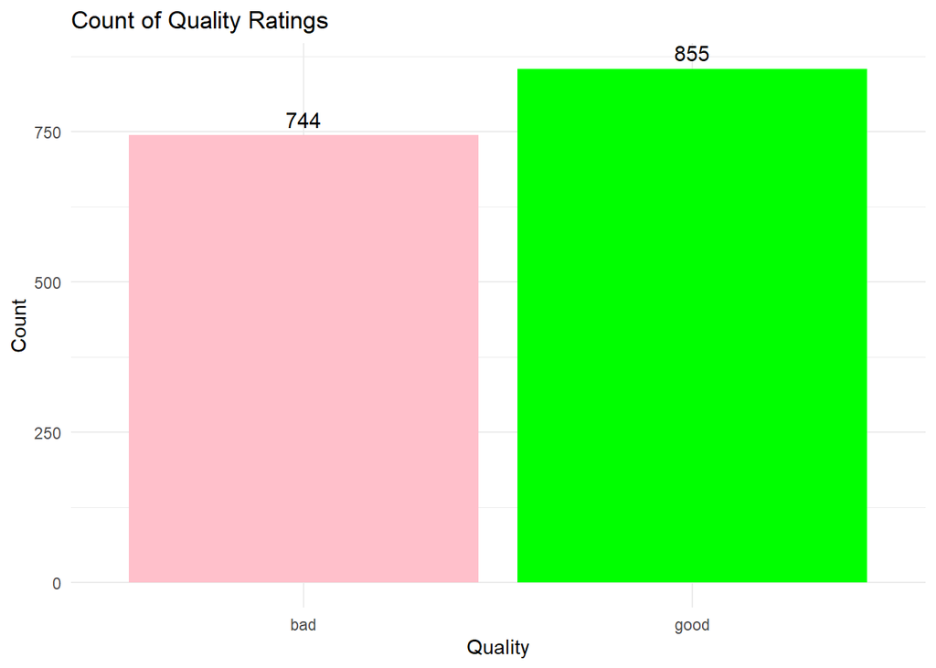

```r
# Count the occurrences of "bad" and "good" in the quality column
quality_counts <- table(df$quality)

# Create a bar plot with count values displayed on top
ggplot(data = NULL, aes(x = names(quality_counts), y = quality_counts)) +
  geom_bar(stat = "identity", fill = c("pink", "green")) +
  geom_text(aes(label = quality_counts), vjust = -0.5, color = "black", size = 4) +  # Add count values on top of bars
  labs(title = "Count of Quality Ratings", x = "Quality", y = "Count") +
  theme_minimal()
```

We have split our data into 25 batches to apply star visualization. As due to lots of records the visualization was not clear and very ambiguous to deduce any hypothesis. But only showing 3 Let’s go through the first three plots. [1] ‘Bad’ is skewed more towards left side, whereas ‘good’ is little contracted from the left side. [2] ‘Bad’ is little contracted while ‘good’ is quite populated in the bottom [3] ‘Bad’ seems to be skewed again towards left side whereas ‘good’ has more regular shape and evenly distributed.

Patterns Revealed: We can say that, there might be a possiblity of left skewedness for ‘bad’ occurences. While evens ones were more evenly distributed and contracted

```r
# Total number of rows in the dataset
total_rows <- nrow(df)

# Calculate the number of rows in each batch
batch_size <- ceiling(total_rows / 25)

# Create a sequence of indices to split the dataset into batches
batch_indices <- seq(1, total_rows, by = batch_size)

# Split the dataset into 25 batches
batches <- lapply(1:(length(batch_indices) - 1), function(i) {
  df[batch_indices[i]:batch_indices[i + 1] - 1, ]
})

# Apply the stars() function to each batch and print as star visualization
for (i in seq_along(batches[1:3])) {  # Iterate over the first three batches only
  cat("\n=============================================\n")
  cat("Batch", i, ":\n\n")
  print(stars(batches[[i]], labels = batches[[i]]$quality))
  cat("\n=============================================\n")
}
```

```
##
## =============================================
## Batch 1 :
```

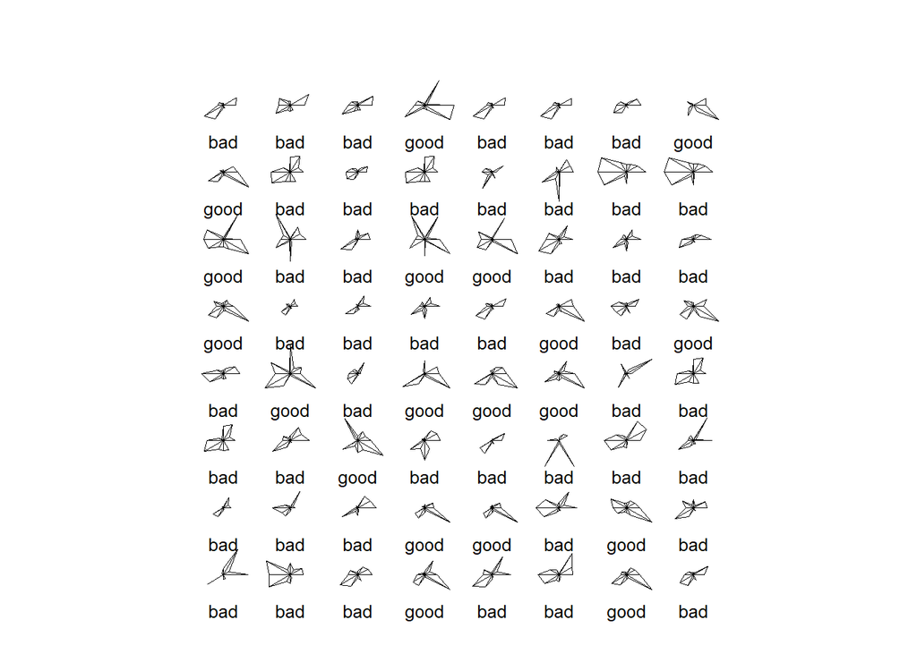

[output not shown]

[output cut: 55 more lines]

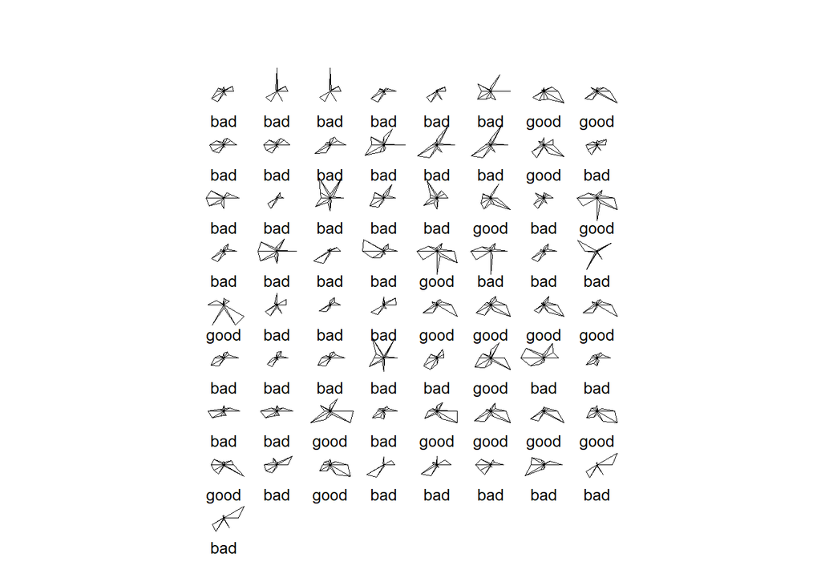

[output not shown]

[output cut: 56 more lines]

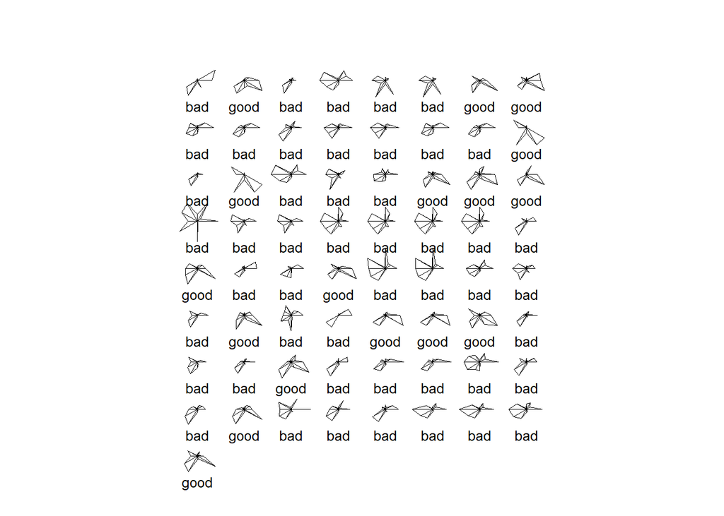

[output not shown]

[output cut: 53 more lines]

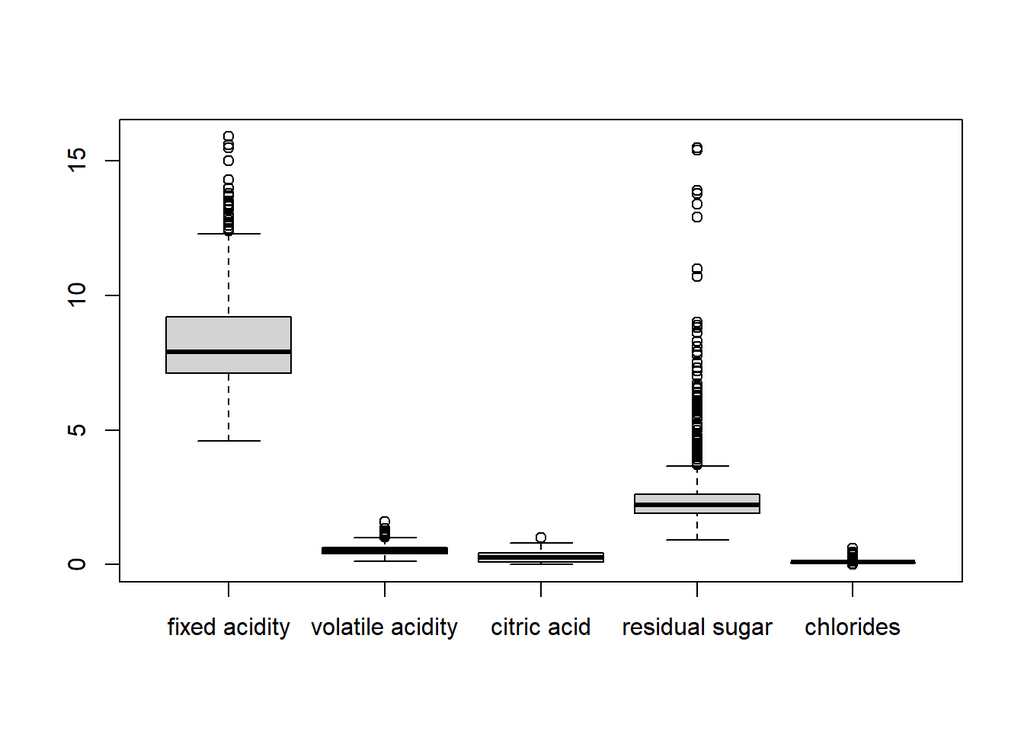

```r
boxplot(df[,1:5])
```

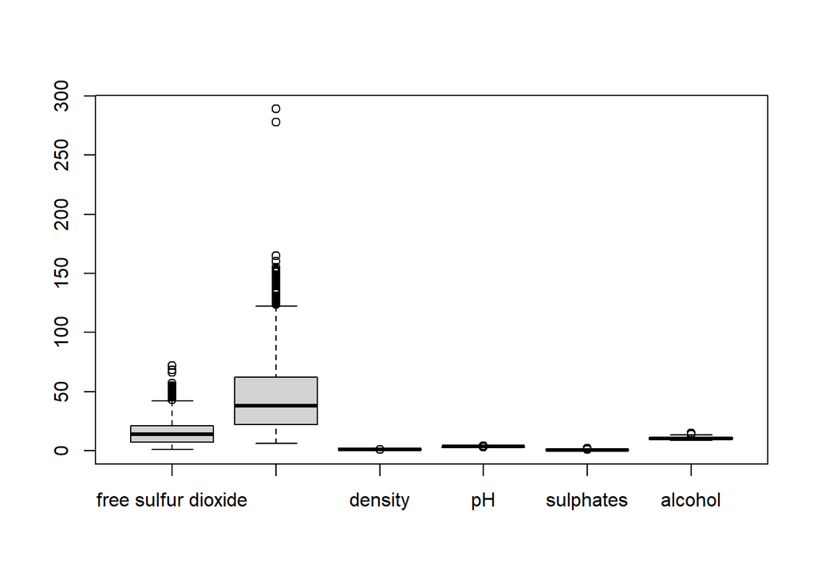

```r
boxplot(df[,6:11])
```

Atlough we cannot see the values clearly, we can observe the attributes having a strong correlation based on color theme.

Observations: Fixed acidity has high correlation with: density and citric acid Total Sulphur dioxide and free sulphur have fairly good correlation PH is negatively correlated to fixed acidity. Volatile acid and citric acid have a fair negative correlation

THere are a few more observations and data seems to have highly related attributes. Which incates we can perform deeper analysis

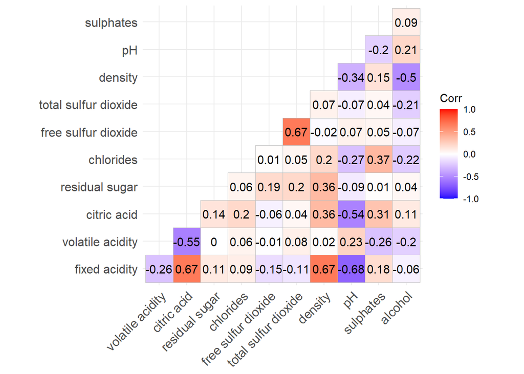

```r
correlation_matrix<- cor(df[,0:11])
ggcorrplot(correlation_matrix,type = "lower", lab = TRUE)
```

We have used one hot encoding just to check correlation of these parameters to good and bad qualtiy of wine

```r
# Define a function to identify categorical columns
is_categorical <- function(col_type) {
  identical(col_type, "character")  # Check if the column type is character
}

# Extract the column names and their data types from the dataframe
col_names <- names(df)
col_types <- sapply(df, class)

# Identify categorical columns in the dataframe
categorical_cols <- col_names[sapply(col_types, is_categorical)]

# Apply one-hot encoding to the categorical columns
dummy_model <- dummyVars(~., data = df[, categorical_cols])
df_categorical_encoded <- predict(dummy_model, newdata = df[, categorical_cols])

# Combine the encoded categorical columns into a single dataframe
df_final <- cbind(df[, !col_names %in% categorical_cols], df_categorical_encoded)

# View the first few rows of the final combined dataframe
head(df_final)
```

```
##   fixed acidity volatile acidity citric acid residual sugar chlorides
## 1           7.4             0.70        0.00            1.9     0.076
## 2           7.8             0.88        0.00            2.6     0.098
## 3           7.8             0.76        0.04            2.3     0.092
## 4          11.2             0.28        0.56            1.9     0.075
## 5           7.4             0.70        0.00            1.9     0.076
## 6           7.4             0.66        0.00            1.8     0.075
##   free sulfur dioxide total sulfur dioxide density   pH sulphates alcohol
## 1                  11                   34  0.9978 3.51      0.56     9.4
## 2                  25                   67  0.9968 3.20      0.68     9.8
## 3                  15                   54  0.9970 3.26      0.65     9.8
## 4                  17                   60  0.9980 3.16      0.58     9.8
## 5                  11                   34  0.9978 3.51      0.56     9.4
## 6                  13                   40  0.9978 3.51      0.56     9.4
##   qualitybad qualitygood
## 1          1           0
## 2          1           0
## 3          1           0
## 4          0           1
## 5          1           0
## 6          1           0
```

Now our data into binary variable for good and bad we can clearly observe that:

[1]Quality of good is positively correlated wit alcohol [2] Whereas bad quality is negatively correlated [3]Same relation with sulphates [4]density, total sulfur dioxide and chlorides are neagtively correlated with good quality and vice versa [5] PH and residual sugar have least correlation to quality of wine Great, now we have identified the features that make wine good and bad.

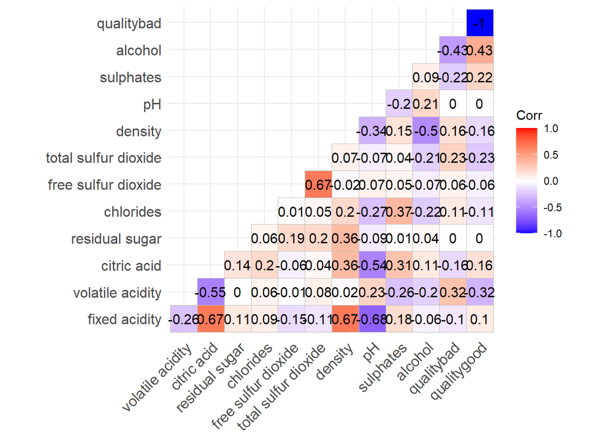

```r
correlation_matrix<- cor(df_final[,1:13])
ggcorrplot(correlation_matrix,type = "lower", lab = TRUE)
```

The matirix elements on the right side seem to be scattered and left ones seem to be clusetered and densely populated. But it is diffcult to come to a conculsion due to difficulty in viewing each element

As per my observation based on 3D Scatter plot

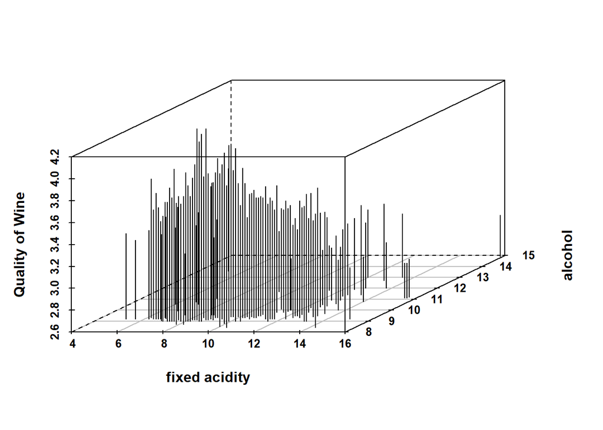

```r
s3d <- scatterplot3d(df$`fixed acidity`, df$alcohol,df$pH,pch=c(1,16)[as.numeric(df$quality)],xlab="fixed acidity", ylab="alcohol", angle=45,zlab="Quality of Wine", lty.hide=2,type="h",y.margin.add=0.1,font.axis=2,font.lab=2)
```

Lets apply this and remove columns that are not correlated Density shows some linear correlation for quality coffee towards edges. pH shows negative correlation for fixed acditiy for both quality coffee towards edges. But difficult to understand due to many elements

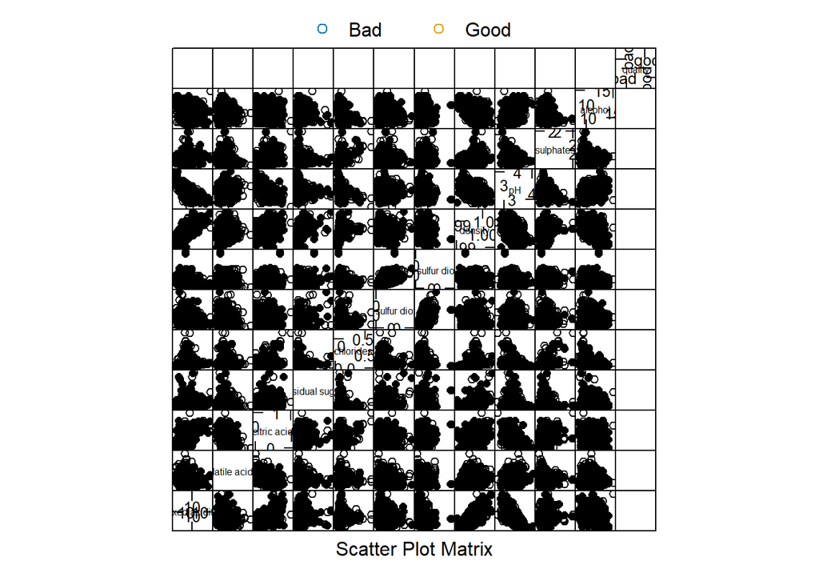

```r
super.sym <- trellis.par.get("superpose.symbol")
super.sym$superpose.symbol$pch <- c(1,16,rep(1,5))
super.sym$superpose.symbol$col <- rep("#000000",7)
trellis.par.set(super.sym)
splom(~df, groups = df$quality, data = df, ps=0.5, varname.cex = .5,panel = panel.superpose,key = list(columns = 2,points = list(pch = super.sym$pch[1:2], col=super.sym$col[1:2]),text = list(c("Bad", "Good"))))
```

Similar for volatile acid but not opposite trend, only observation is it is not overlapping unlike other variables

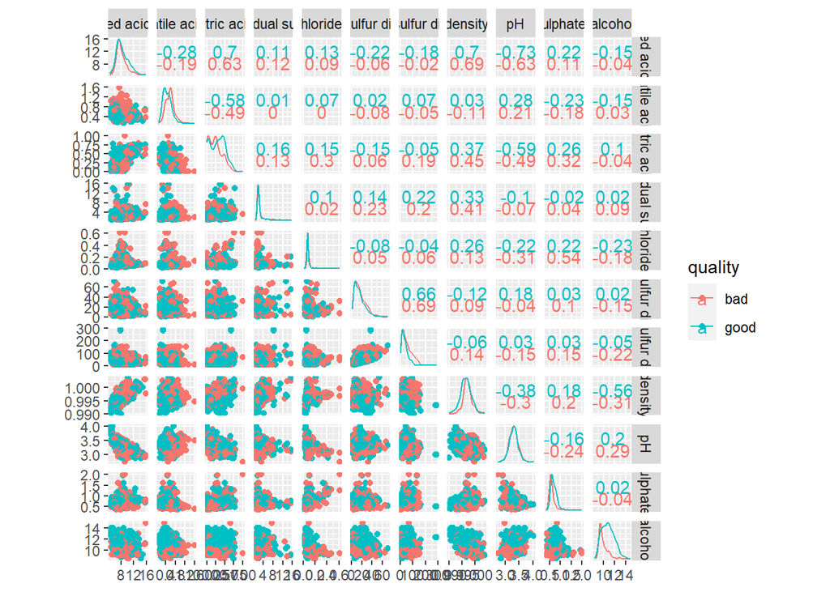

```r
ggscatmat(df, columns=1:12, color="quality")
```

Density seems to be negatively correlated to alcohol content, possibly could be density of other contents to wine leading to low quality as high alcohol score has been graded as good quality

```r
# Create a data frame from your existing 'df' object
df1 <- df_final[!sapply(df_final, is.function)]

# Attach the 'df' data frame to the search path
attach(df)
df
```

```
## # A tibble: 1,599 × 12
##    `fixed acidity` `volatile acidity` `citric acid` `residual sugar` chlorides
##              <dbl>              <dbl>         <dbl>            <dbl>     <dbl>
##  1             7.4               0.7           0                 1.9     0.076
##  2             7.8               0.88          0                 2.6     0.098
##  3             7.8               0.76          0.04              2.3     0.092
##  4            11.2               0.28          0.56              1.9     0.075
##  5             7.4               0.7           0                 1.9     0.076
##  6             7.4               0.66          0                 1.8     0.075
##  7             7.9               0.6           0.06              1.6     0.069
##  8             7.3               0.65          0                 1.2     0.065
##  9             7.8               0.58          0.02              2       0.073
## 10             7.5               0.5           0.36              6.1     0.071
## # ℹ 1,589 more rows
## # ℹ 7 more variables: `free sulfur dioxide` <dbl>,
## #   `total sulfur dioxide` <dbl>, density <dbl>, pH <dbl>, sulphates <dbl>,
## #   alcohol <dbl>, quality <chr>
```

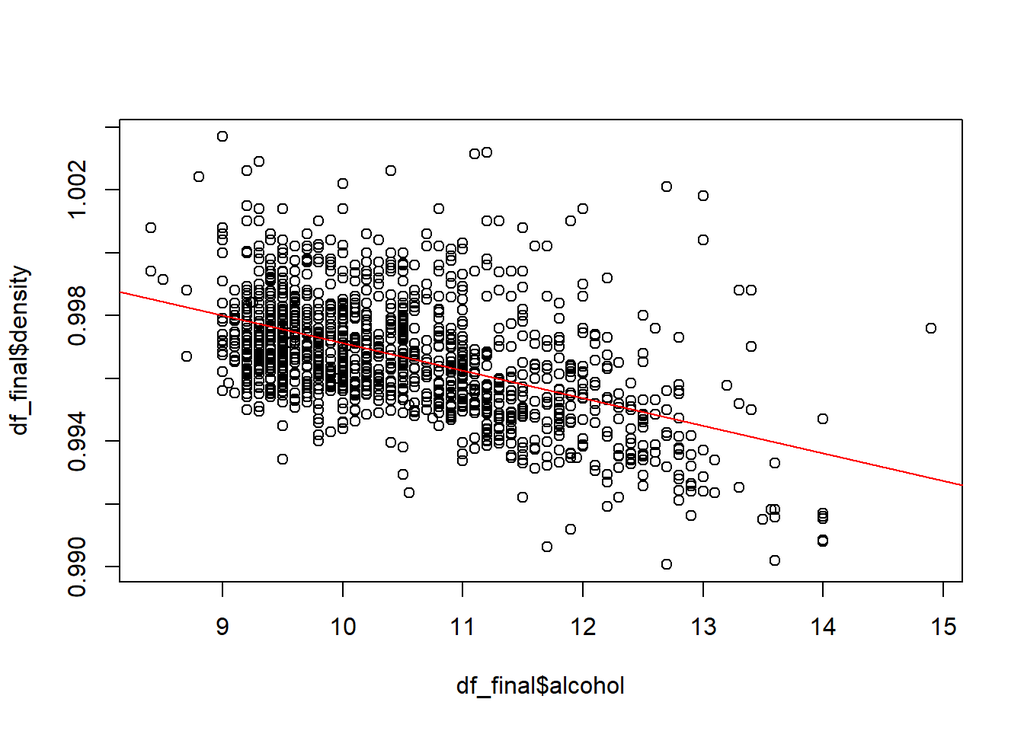

```r
# Now you can use variables in 'df' directly without referencing the data frame
plot(df_final$density ~ df_final$alcohol)
abline(lm(df_final$density ~ df_final$alcohol), col = "red")
```

We can check citric acid content and its relation to pH: As per observation we can infer that pH is negatively correlated to citric acid content. This matches the knowledge we have, high pH = Less acidity

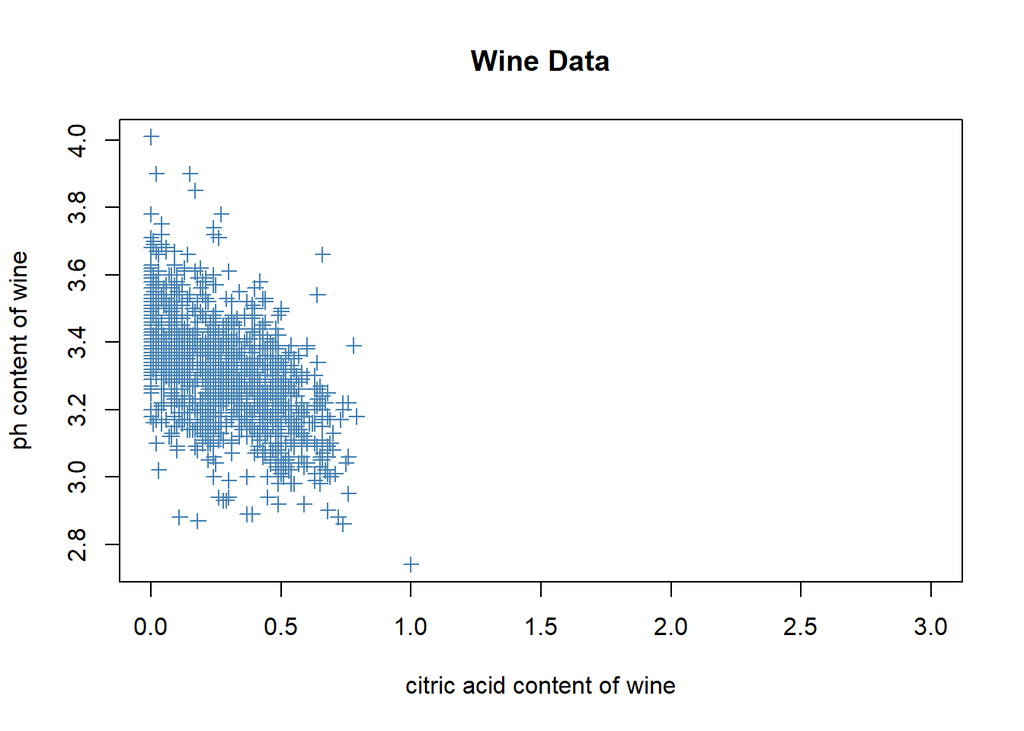

```r
plot(pH ~ `citric acid`, col="steelblue", pch=3, main="Wine Data", xlab="citric acid content of wine",
     ylab="ph content of wine", xlim=c(0,3))
```

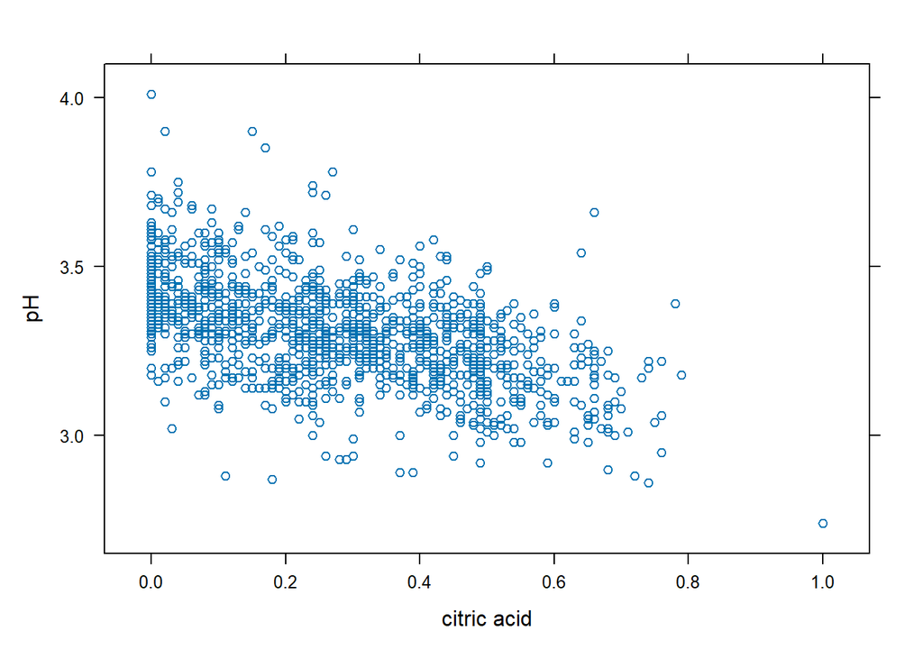

```r
xyplot(pH ~ `citric acid`)
```

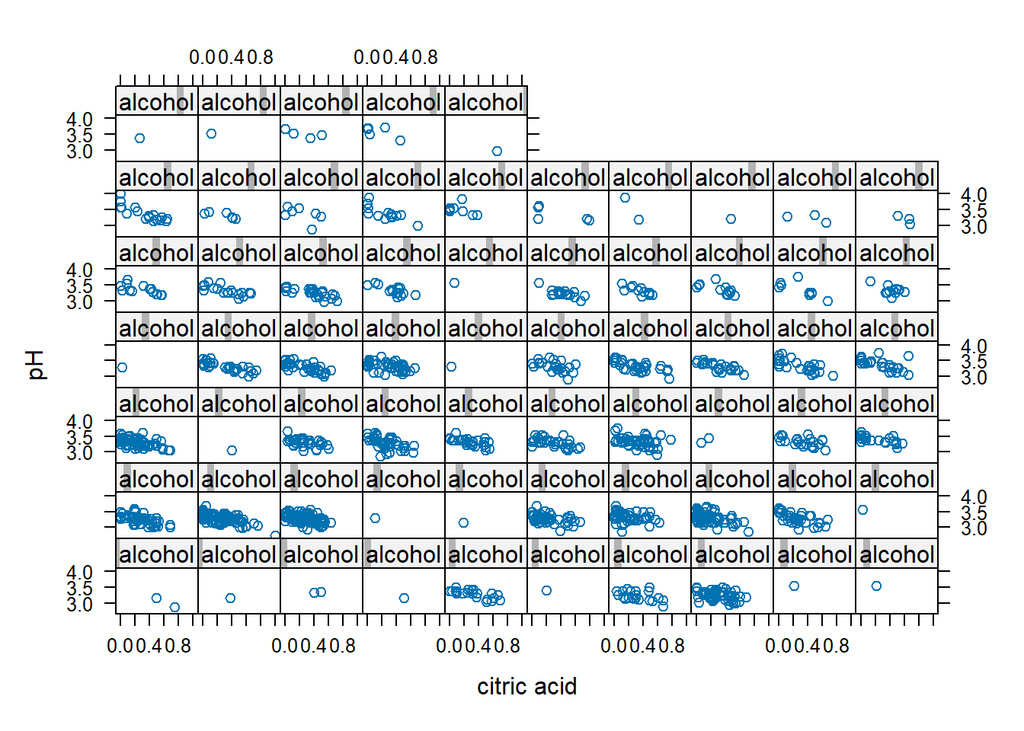

```r
xyplot(pH ~ `citric acid` | alcohol)
```

[figure not shown]

```r
xyplot(pH ~ `citric acid` | `residual sugar` + alcohol)
```

Comparing correlated variable observed earlier but we can see they both follow a similar pattern as per scatter plot. But we can make one inference that as alcohol increases we observe volatile acidity decreasing.

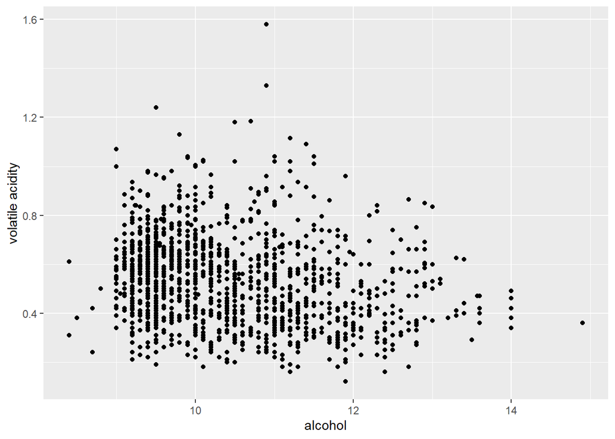

```r
# ggplot
ggplot(df, aes(x = alcohol, y = `volatile acidity`)) + geom_point()
```

Lets use onehot encode data to get a clear picture: We can see that good quality coffee in the first plot and inverse for bad quality coffee

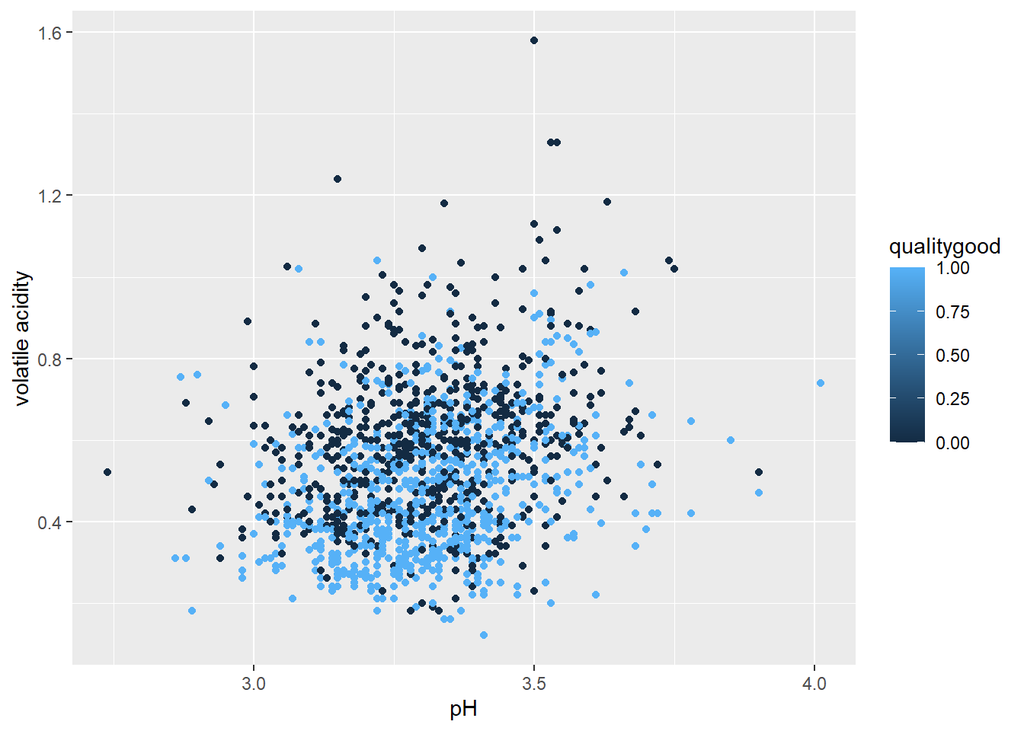

```r
ggplot(df_final, aes(x = pH, y = `volatile acidity`)) + geom_point(aes(color = `qualitygood`))
```

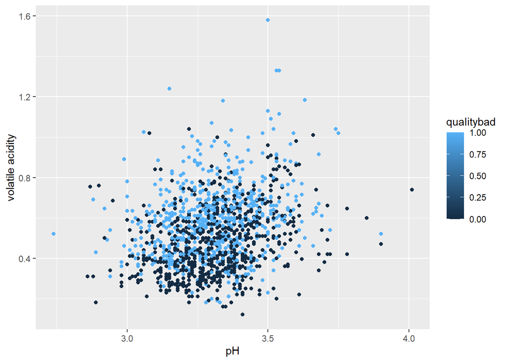

```r
ggplot(df_final, aes(x = pH, y = `volatile acidity`)) + geom_point(aes(color = `qualitybad`))
```

Alcohol seems to be undeffected by residual sugar like other columns hence won’t be used for multivariate models

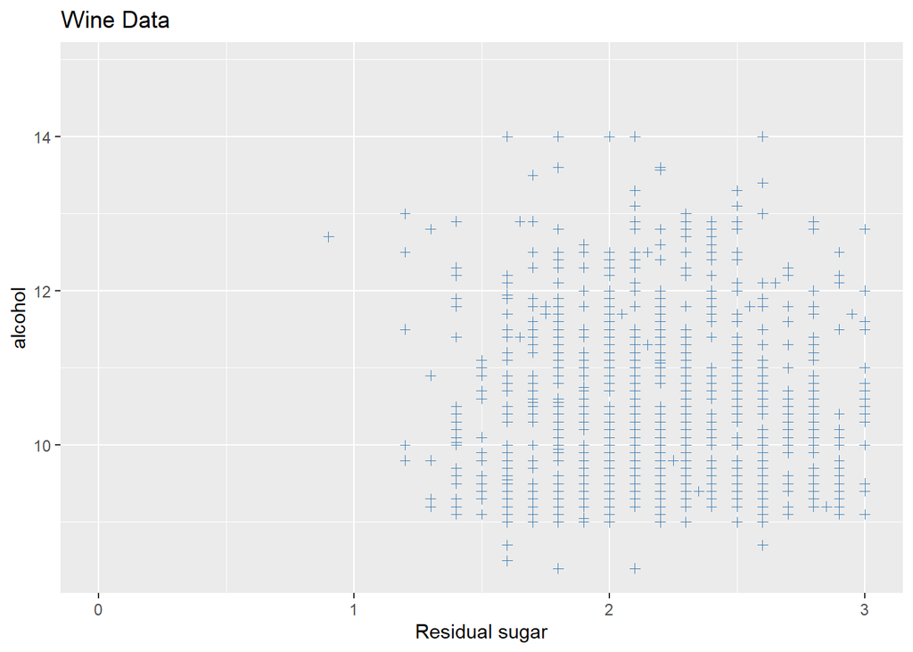

```r
ggplot(df_final, aes(x = `residual sugar`, y = `alcohol`)) + xlim(0, 3) + geom_point(colour = "steelblue", pch = 3) +
  labs(x = "Residual sugar", y = "alcohol", title = "Wine Data")
```

Total sulphur dioxide is less for most of the dataset as per histogram plot. Same for volatile acidity but it is more evenly distributed towards midpoint.

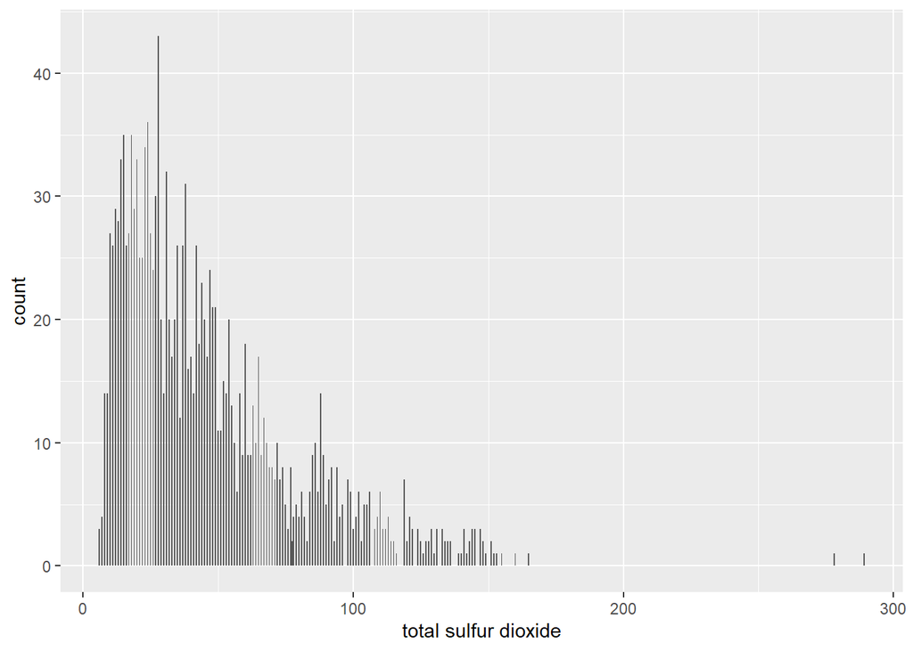

```r
# bar chart
ggplot(df, aes(`total sulfur dioxide`)) + geom_bar(position = "stack")
```

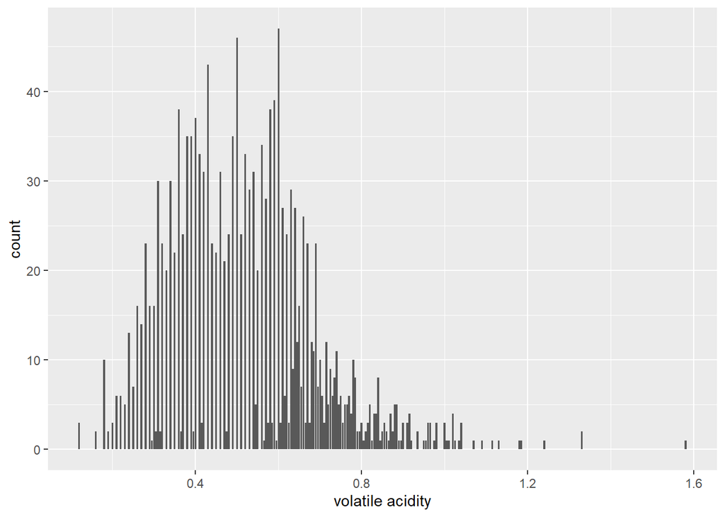

```r
ggplot(df, aes(`volatile acidity`)) + geom_bar(position = "stack")
```

There are less records for high alcohol content in entire data frame as histogram is skewed towards right

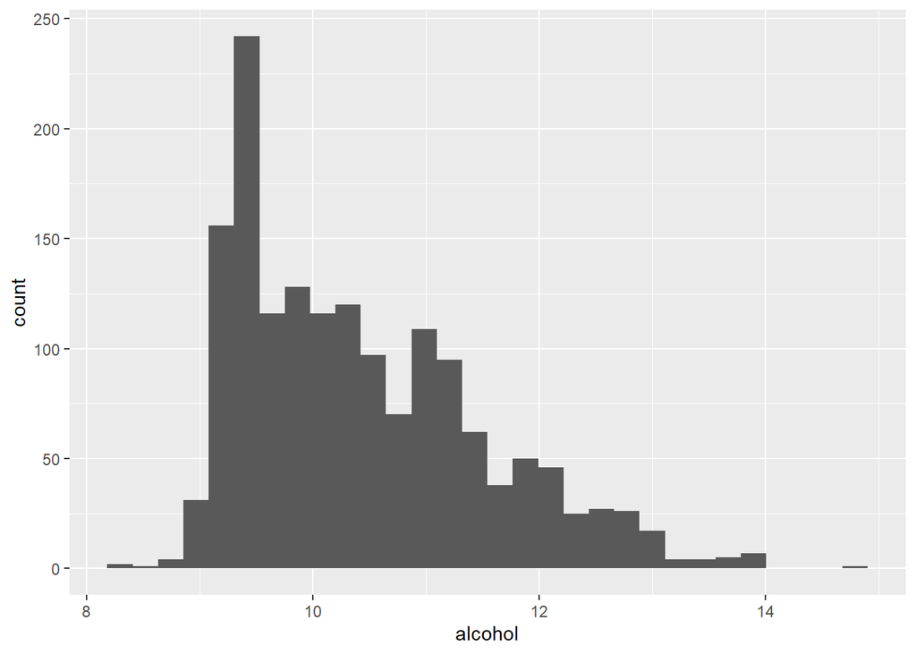

```r
# histogram
ggplot(df, aes(alcohol)) + geom_histogram()
```

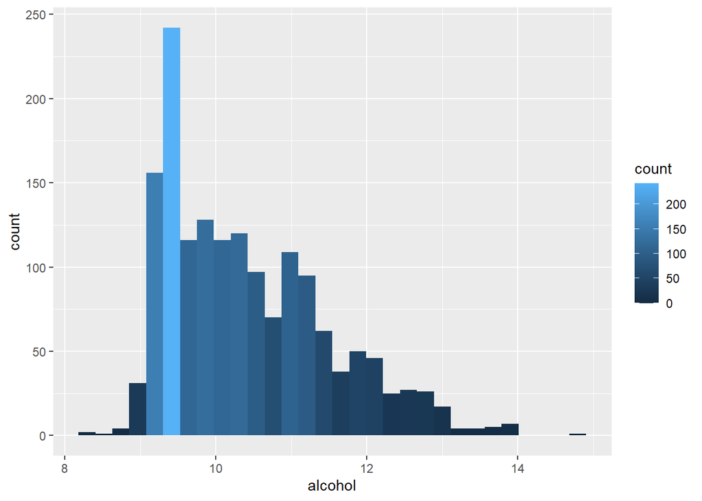

```r
ggplot(df, aes(alcohol)) + geom_histogram(aes(fill = after_stat(count)))
```

As per regression we can determine that alcohol is inveresly correlated to volatile acidity as the slope is negative.

We can also confirm on our hypothesis that citric acid is inversely correlated to pH content in wine as per the negative slope

As per regression model for stat_smooth we can detemrine that as the volatile acidity increase wine quality rating will drop further

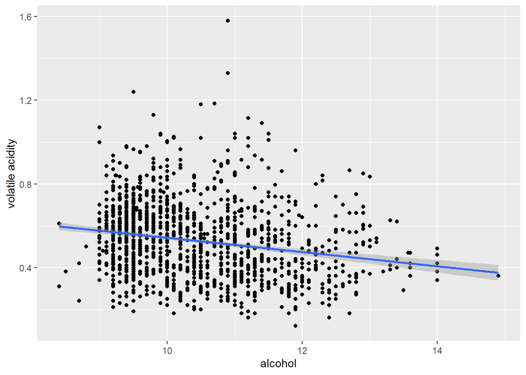

```r
# regression
ggplot(df, aes(x = alcohol, y = `volatile acidity`)) + geom_point() + geom_smooth(method = lm)
```

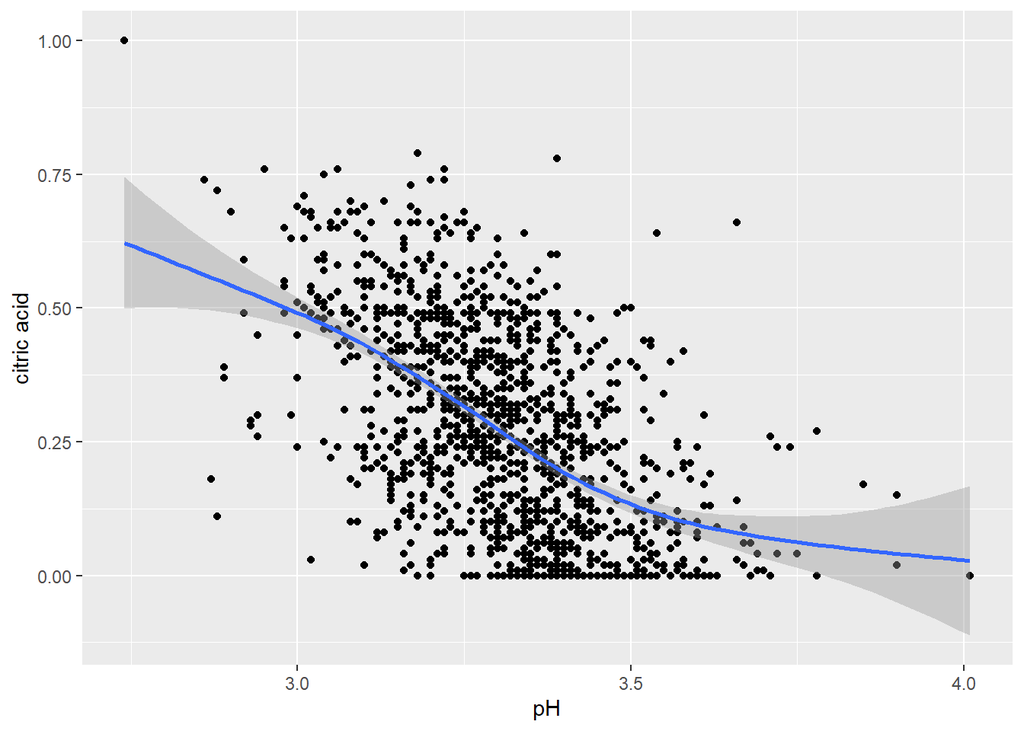

```r
ggplot(df, aes(x = pH, y = `citric acid`)) + geom_point() + stat_smooth()
```

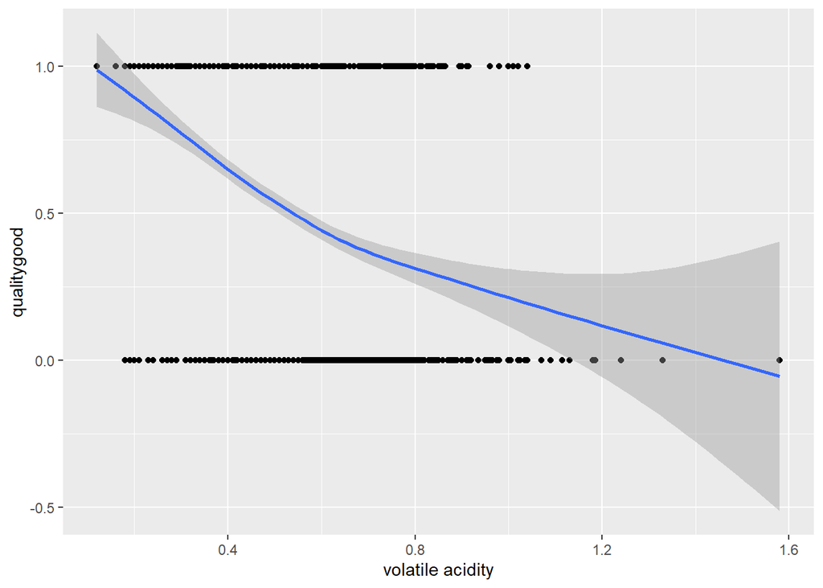

```r
ggplot(df_final, aes(x = `volatile acidity`, y = `qualitygood`)) + geom_point() + stat_smooth()
```

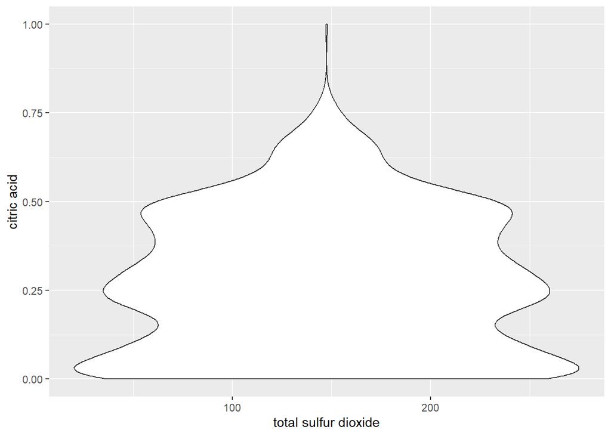

```r
# violin plot
ggplot(df, aes(x = `total sulfur dioxide`, y = `citric acid`)) + geom_violin()
```